# Geog533 Lab 8

Complete the following exercises in Chapter 8 (Introduction to Regression Analysis) of the textbook [R] pages 247-250.

## Question 1

This is Exercise 1 in Chapter 8 of the Textbook [R].

A regression of weekly shopping trip frequency on annual income (data entered in thousands of dollars) is performed on data collected from 24 respondents. The results are summarized below:

- Intercept: 0.46
- Slope: 0.19

|  | Sum of squares | Degrees of freedom | Mean square | *F* |
| --- | --- | --- | --- | --- |
| Regression |  |  |  |  |
| Residual | 1.7 |  |  |  |
| Total | 2.3 |  |  |  |

### Question 1(a)

Fill in the blanks in the ANOVA table.

```r
ssr1 <- 1.7
sst1 <- 2.3
n <- 24
ssm1 <- sst1 - ssr1
df11 <- 1
df21 <- n - 2
dft1 <- n - 1
msm1 <- ssm1/1
msr1 <- ssr1/(n-2)
f1 <- msm1/msr1
```

|  | Sum of squares | Degrees of freedom | Mean square | *F* |
| --- | --- | --- | --- | --- |
| Regression | 0.6 | 1 | 0.6 | 7.7647059 |
| Residual | 1.7 | 22 | 0.0772727 |  |
| Total | 2.3 | 23 |  |  |

### Question 1(b)

What is the predicted number of weekly shopping trips for someone making $50,000/year?

```r
a <- 0.46
b <- 0.19
x1 <- 50
y1 <- b*x1 + a
y1
```

```
[1] 9.96
```

```r
#predicted number of weekly shopping trips is 9.96
```

### Question 1(c)

In words, what is the meaning of the coefficient 0.19?

Answer: when one unit increases in annual income, the weekly shopping trip frequency will increase 0.19.

### Question 1(d)

Is the regression coefficient significantly different from zero? How do you know?

```r
f_critical <- qf(0.95,df1 = 1,df2 = 22)
if(f1 > f_critical){
  print("we reject the non hypothesis")
}else {
  print("we can not reject non hypothesis")
}
```

```
[1] "we reject the non hypothesis"
```

```r
#regression cofficient significantly different form zero
```

### Question 1(e)

What is the value of the correlation coefficient?

```r
R <- sqrt(ssm1/sst1)
R
```

```
[1] 0.5107539
```

```r
# the correlation coefficient value is 0.5107539
```

## Question 2

This is Exercise 6 in Chapter 8 of the Textbook [R].

The following data are collected in an effort to determine whether snowfall is dependent upon elevation:

| Snowfall (inches) | Elevation (feet) |
| --- | --- |
| 36 | 400 |
| 78 | 800 |
| 11 | 200 |
| 45 | 675 |

Using R, show your work on exercises (a) through (g).

### Question 2(a)

Find the regression coefficients (the intercept and the slope coefficient).

```r
sn <- c(36,78,11,45)
el <- c(400,800,200,675)
df <- data.frame(el,sn)
m <- lm(df$sn~df$el)
summary(m)
```

```
Call:
lm(formula = df$sn ~ df$el)

Residuals:
       1        2        3        4
  4.9772   8.3172  -0.6928 -12.6016

Coefficients:
            Estimate Std. Error t value Pr(>|t|)
(Intercept) -7.63721   13.67764  -0.558   0.6328
df$el        0.09665    0.02403   4.022   0.0566 .
---
Signif. codes:  0 ‘***’ 0.001 ‘**’ 0.01 ‘*’ 0.05 ‘.’ 0.1 ‘ ’ 1

Residual standard error: 11.25 on 2 degrees of freedom
Multiple R-squared:  0.8899,    Adjusted R-squared:  0.8349
F-statistic: 16.17 on 1 and 2 DF,  p-value: 0.05663
```

```r
m$coefficients
```

```
(Intercept)       df$el
-7.63720599  0.09665004
```

```r
# intercept and slope are not significant
```

### Question 2(b)

Estimate the standard error of the residuals about the regression line.

```r
result <- summary(m)
residual_sd <- result$sigma
residual_sd
```

```
[1] 11.25227
```

### Question 2(c)

Test the hypothesis that the regression coefficient associated with the independent variables is equal to zero. Also place a 95% confidence interval on the regression coefficient.

```r
result <- summary(m)
result
```

```
Call:
lm(formula = df$sn ~ df$el)

Residuals:
       1        2        3        4
  4.9772   8.3172  -0.6928 -12.6016

Coefficients:
            Estimate Std. Error t value Pr(>|t|)
(Intercept) -7.63721   13.67764  -0.558   0.6328
df$el        0.09665    0.02403   4.022   0.0566 .
---
Signif. codes:  0 ‘***’ 0.001 ‘**’ 0.01 ‘*’ 0.05 ‘.’ 0.1 ‘ ’ 1

Residual standard error: 11.25 on 2 degrees of freedom
Multiple R-squared:  0.8899,    Adjusted R-squared:  0.8349
F-statistic: 16.17 on 1 and 2 DF,  p-value: 0.05663
```

```r
if(result$coefficients[1,4] > 0.05){
  print("we can not reject non hypothesis")
}
```

```
[1] "we can not reject non hypothesis"
```

```r
c_f <- qf(0.95,df1 = 1,df2 = 2)
if(result$fstatistic < c_f){
  print("regression coefficient is equal to zero")
}
```

```
[1] "regression coefficient is equal to zero"
```

### Question 2(d)

Find the value of $r^2$.

```r
result$r.squared
```

```
[1] 0.889949
```

```r
#the value of r^2 is 0.889949
```

### Question 2(e)

Make a table of the observed values, predicted values, and the residuals.

```r
library(knitr)
ob_v <- df$sn
pre_v <- m$fitted.values
res_v <- m$residuals
df_tab <- data.frame(ob_v,pre_v,res_v)
kable(df_tab)
```

| ob_v | pre_v | res_v |
| --- | --- | --- |
| 36 | 31.02281 | 4.9771917 |
| 78 | 69.68282 | 8.3171775 |
| 11 | 11.69280 | -0.6928011 |
| 45 | 57.60157 | -12.6015681 |

### Question 2(f)

Prepare an analysis of variance table portraying the regression results.

```r
result_a <- anova(m)
result_a
```

```
Analysis of Variance Table

Response: df$sn
          Df  Sum Sq Mean Sq F value  Pr(>F)
df$el      1 2047.77 2047.77  16.173 0.05663 .
Residuals  2  253.23  126.61
---
Signif. codes:  0 ‘***’ 0.001 ‘**’ 0.01 ‘*’ 0.05 ‘.’ 0.1 ‘ ’ 1
```

```r
df1 <- result_a$Df[1]
df2 <- result_a[2,1]
ssm <- result_a$`Sum Sq`[1]
ssr <- result_a$`Sum Sq`[2]
sst <- ssm + ssr
dft <- df1 + df2
msm <- result_a$`Mean Sq`[1]
msr <- result_a$`Mean Sq`[2]
f <- msm/msr
```

|  | Sum of squares | Degrees of freedom | Mean square | *F* |
| --- | --- | --- | --- | --- |
| Regression | 2047.7726301 | 1 | 2047.7726301 | 16.173391 |
| Residual | 253.2273699 | 2 | 126.613685 |  |
| Total | 2301 | 3 |  |  |

### Question 2(g)

Graph the data and the regression line.

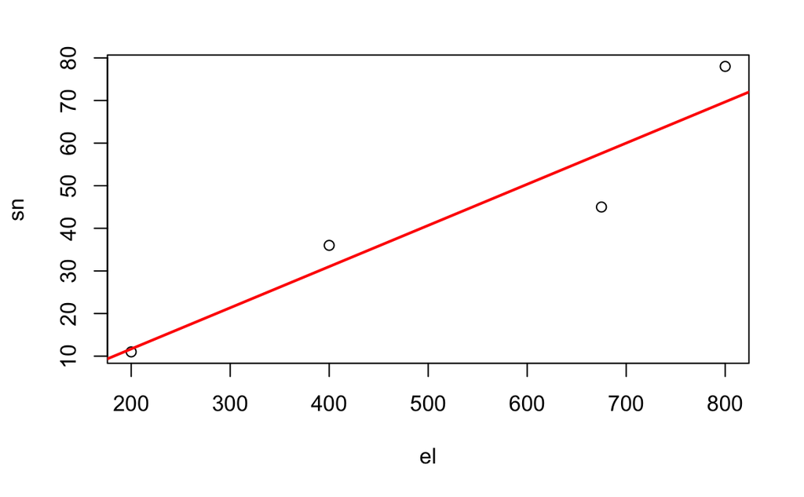

```r
plot(df)
abline(m,col = "red",lwd = 2)
```

## Question 3

This is Exercise 10 in Chapter 8 of the Textbook [R].

Use R and the [Milwaukee dataset](http://spatial.binghamton.edu/geog533/data/Milwaukee_Sales.csv) to:

### Problem

perform a regression using sales price as the dependent variable and lot size as the independent variable.

### Solution

```r
url = "http://spatial.binghamton.edu/geog533/data/Milwaukee_Sales.csv"
df3 <- read.csv(url, header = T)
m <- lm(df3$SalePrice~df3$LotSize)
m
```

```
Call:
lm(formula = df3$SalePrice ~ df3$LotSize)

Coefficients:
(Intercept)  df3$LotSize
  92984.248        6.443
```

```r
result3 <- summary(m)
result3
```

```
Call:
lm(formula = df3$SalePrice ~ df3$LotSize)

Residuals:
    Min      1Q  Median      3Q     Max
-144724  -42205  -14553   20987  808570

Coefficients:
             Estimate Std. Error t value Pr(>|t|)
(Intercept) 9.298e+04  5.249e+03  17.715  < 2e-16 ***
df3$LotSize 6.443e+00  7.835e-01   8.223 4.37e-16 ***
---
Signif. codes:  0 ‘***’ 0.001 ‘**’ 0.01 ‘*’ 0.05 ‘.’ 0.1 ‘ ’ 1

Residual standard error: 83090 on 1447 degrees of freedom
Multiple R-squared:  0.04464,   Adjusted R-squared:  0.04398
F-statistic: 67.62 on 1 and 1447 DF,  p-value: 4.374e-16
```

```r
f_c <- qf(0.95,df1 = 1,df2 = nrow(df3)-2)
if(result3$fstatistic[1] > f_c){
  print("we reject non hypothesis, regression coefficient is significant.")
}else{
  print("we can not reject non hypothesis")
}
```

```
[1] "we reject non hypothesis, regression coefficient is significant."
```

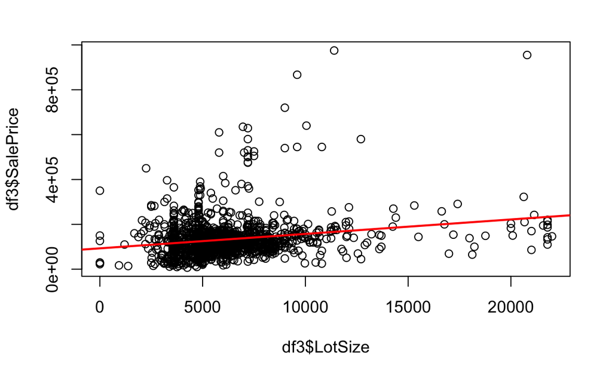

```r
plot(df3$LotSize,df3$SalePrice)
abline(m,col = "red",lwd = 2)
```

## Question 4

This is Exercise 11 in Chapter 8 of the Textbook [R].

Use R and the Hypothetical [UK Housing Prices dataset](http://spatial.binghamton.edu/geog533/data/UK_Housing.csv) to:

### Question 4(a)

perform a regression using house price as the dependent variable, and number of bedrooms as the independent variable;

```r
url = "http://spatial.binghamton.edu/geog533/data/UK_Housing.csv"
df4 <- read.csv(url,header = T)
m <- lm(df4$price~df4$bedrooms)
m
```

```
Call:
lm(formula = df4$price ~ df4$bedrooms)

Coefficients:
 (Intercept)  df4$bedrooms
       11254         11893
```

```r
result4a <- summary(m)
result4a
```

```
Call:
lm(formula = df4$price ~ df4$bedrooms)

Residuals:
   Min     1Q Median     3Q    Max
-39324 -11511  -3539   8461 107568

Coefficients:
             Estimate Std. Error t value Pr(>|t|)
(Intercept)   11254.1     2312.7   4.866 1.53e-06 ***
df4$bedrooms  11892.6      876.5  13.568  < 2e-16 ***
---
Signif. codes:  0 ‘***’ 0.001 ‘**’ 0.01 ‘*’ 0.05 ‘.’ 0.1 ‘ ’ 1

Residual standard error: 17800 on 497 degrees of freedom
Multiple R-squared:  0.2703,    Adjusted R-squared:  0.2688
F-statistic: 184.1 on 1 and 497 DF,  p-value: < 2.2e-16
```

```r
f_c <- qf(0.95,df1 = 1,df2 = nrow(df4)-2)
if(result4a$fstatistic[1] > f_c){
  print("we reject non hypothesis, regression coefficient is significant.")
}else{
  print("we can not reject non hypothesis")
}
```

```
[1] "we reject non hypothesis, regression coefficient is significant."
```

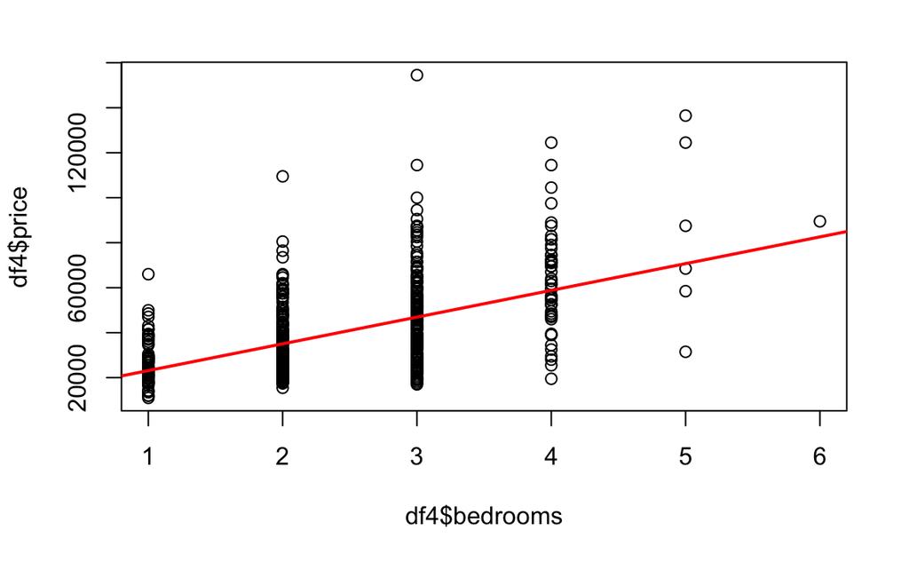

```r
plot(df4$bedrooms,df4$price)
abline(m,col = "red",lwd = 2)
```

### Question 4(b)

2. repeat part (a), using the number of bathrooms as the independent variable, and comment on the results.

```r
m <- lm(df4$price~df4$bathrooms)
m
```

```
Call:
lm(formula = df4$price ~ df4$bathrooms)

Coefficients:
  (Intercept)  df4$bathrooms
        32729           7113
```

```r
result4b <- summary(m)
result4b
```

```
Call:
lm(formula = df4$price ~ df4$bathrooms)

Residuals:
   Min     1Q Median     3Q    Max
-34955 -15242  -5342  10908 114658

Coefficients:
              Estimate Std. Error t value Pr(>|t|)
(Intercept)      32729       3149  10.394  < 2e-16 ***
df4$bathrooms     7113       2682   2.653  0.00824 **
---
Signif. codes:  0 ‘***’ 0.001 ‘**’ 0.01 ‘*’ 0.05 ‘.’ 0.1 ‘ ’ 1

Residual standard error: 20690 on 497 degrees of freedom
Multiple R-squared:  0.01396,   Adjusted R-squared:  0.01198
F-statistic: 7.036 on 1 and 497 DF,  p-value: 0.008245
```

```r
if(result4b$fstatistic[1] > f_c){
  print("we reject non hypothesis, regression coefficient is significant.")
}else{
  print("we can not reject non hypothesis")
}
```

```
[1] "we reject non hypothesis, regression coefficient is significant."
```

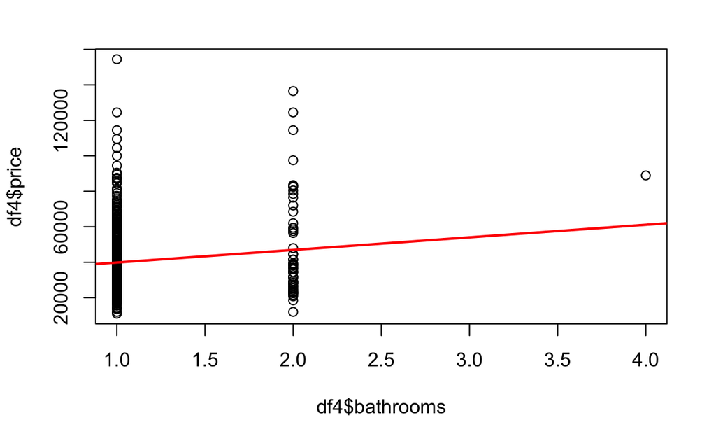

```r
plot(df4$bathrooms,df4$price)
abline(m,col = "red",lwd = 2)
```

## Question 5

Download the hometown.csv, append your name and hometown coordinates to the csv, then use [leaflet](https://rstudio.github.io/leaflet/) to create a web map (10 pt.)

```r
if(!require(leaflet)) {install.packages("leaflet")}
library(leaflet)
df <- read.csv(file = "https://xujianzi.github.io/data/hometown1.csv",header = T)
content <- paste(sep = "<br/>",
                 "<b><a href='https://xujianzi.github.io/data/WechatIMG75.jpeg'>Jian Xu</a></b>",
                 "Yufeng International ",
                 "Tianxian road"
)
m <- leaflet(data = df,width = "100%") %>%
  addTiles() %>%  # Add default OpenStreetMap map tiles
  addMarkers(~longitude,~latitude,popup = ~fullname,label = ~image) %>%
  addPopups(113.8660792,30.9191275,content,options = popupOptions(closeButton = F))
m  # Print the map
```

[interactive chart not shown]